# Patient Behavior Factorial: Average-Utilization Optimization

Findings-led 3×3 analysis of Class 1 no-show and balking sensitivity

This report asks one question: **which Class 1 behavior changes the utilization value of scheduling policy, and under what clinic conditions?**

Average utilization is the share of measured appointment capacity that becomes completed visits:

$$U = \frac{Y_1 + Y_2}{M},$$

where $Y_1$ and $Y_2$ are completed Class 1 and Class 2 visits and $M$ is measured appointment capacity.

The headline analysis uses $\rho=1.2,1.4,1.7,2.0,$ and $2.5$. The $\rho=3.0$ setting is retained as a heavy-demand stress condition.

# 1 3×3 behavior experiment

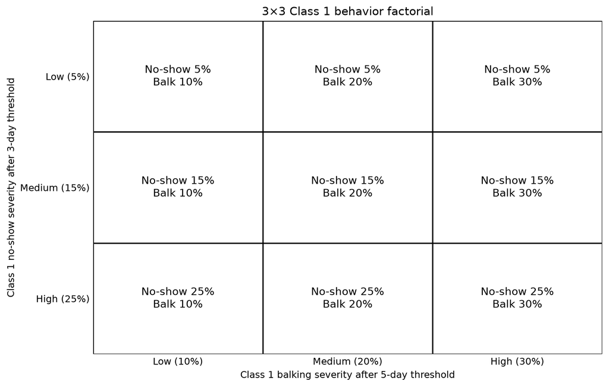

The 3×3 Class 1 behavior design. Moving vertically changes no-show severity; moving horizontally changes balking severity.

The design isolates **severity**, not threshold timing:

- No-show threshold: **3 days**
- Balking threshold: **5 days**
- Pre-threshold probability: **5%** for both behaviors
- Class 2 behavior is fixed throughout

Each behavior cell is compared with its **own matched no-policy baseline** with the same behavior values, demand, Class 1 share, and capacity.

The 3×3 cells are crossed with six demand levels, five Class 1 shares, and two capacities: **540 backgrounds total**, including **450** in the headline range.

| Policy | Booking horizon | Reservation |
| --- | --- | --- |
| Baseline | 100 days | None |
| Horizon only | Optimized over 2–26 days | None |
| Reservation only | 100 days | Quantity/window optimized |
| Both flexible | Optimized over 2–26 days | Quantity/window optimized |

# 2 Finding 1 — No-show severity determines the utilization value of policy

**High no-show produces the largest utilization benefit from policy change.** Low no-show produces almost no median gain; medium no-show produces a moderate gain; high no-show produces the largest gain under every optimized policy.

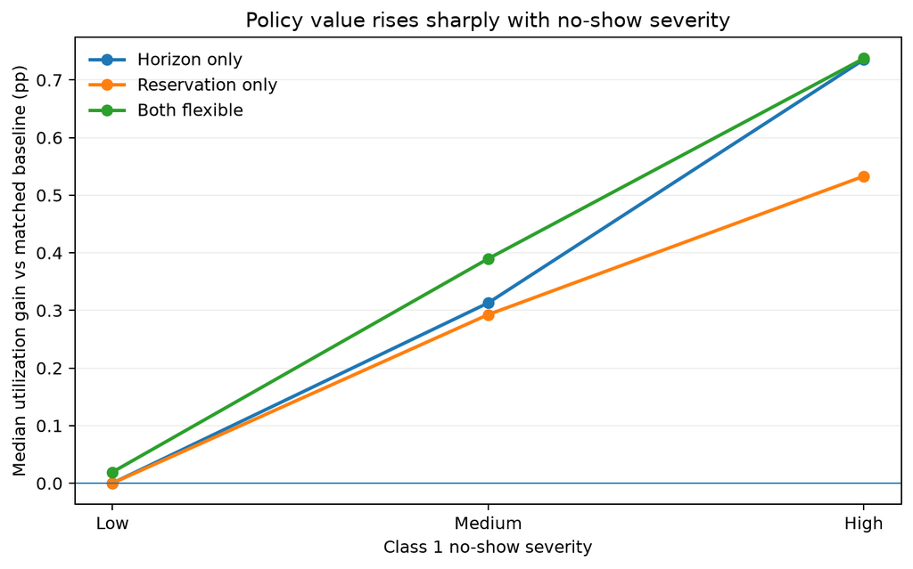

Median utilization value rises strongly from low to high no-show severity for all three policies.

The 3×3 cell medians make the pattern concrete:

| Policy | Low no-show | Medium no-show | High no-show |
| --- | --- | --- | --- |
| Horizon only | ~0.00 pp | ~+0.32 pp | **~+0.73 pp** |
| Reservation only | ~0.00 pp | ~+0.29 pp | **~+0.53 pp** |
| Both flexible | ~+0.02 pp | ~+0.38 pp | **~+0.75 pp** |

**Evidence from the matched factorial contrasts:**

| Policy | No-show low → high | Balking low → high |
| --- | --- | --- |
| Horizon only | **+2.11 pp** | −0.03 pp |
| Reservation only | **+1.18 pp** | −0.02 pp |
| Both flexible | **+2.11 pp** | −0.03 pp |

The policy value is therefore primarily a response to **delay-sensitive no-show risk**, not to patient attrition in general.

# 3 Finding 2 — Balking has little main effect, and it does not materially change the no-show effect

Two conclusions follow directly from the 3×3 design:

1. **Balking severity does not have a comparable main effect on utilization.**
2. **The no-show effect is largely stable across balking levels.**

Within each no-show row, moving from low to high balking changes the median utilization gain by only a few hundredths of a percentage point.

Examples:

- Horizon only, high no-show: **+0.74 / +0.73 / +0.73 pp** across low / medium / high balking.
- Reservation only, high no-show: **+0.53 / +0.53 / +0.53 pp**.
- Both flexible, high no-show: **+0.77 / +0.75 / +0.74 pp**.

The formal no-show × balking interaction is also very small: approximately **−0.05 to −0.06 pp** across the three policies.

**Interpretation:** higher balking does not materially amplify or suppress the utilization opportunity created by higher no-show risk.

# 4 Finding 3 — Congestion activates the no-show effect

The behavioral difference matters only when delays become long enough to cross the **3-day no-show threshold**.

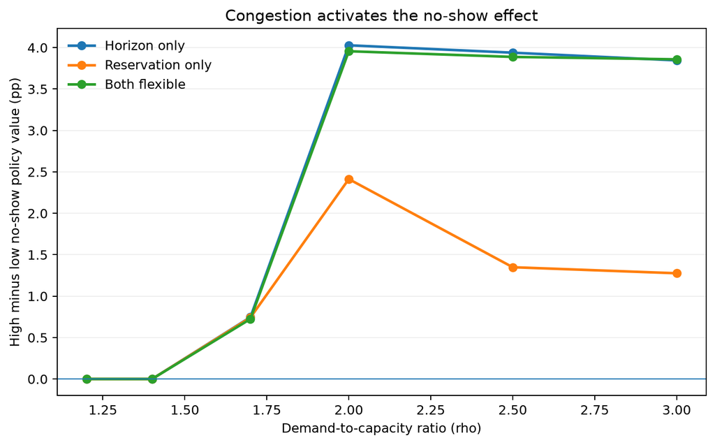

The utilization-value difference between high and low no-show severity is small at low demand and grows as congestion increases.

- At $\rho=1.2$ and $1.4$, policy has little utilization value because offered delays rarely activate the behavior thresholds.
- The no-show separation begins to matter around $\rho=1.7$.
- It becomes operationally important around $\rho=2.0$–$2.5$.
- $\rho=3.0$ is best interpreted as a stress condition rather than part of the headline range.

This explains why the pooled mean policy effect is much larger than the pooled median: **policy value is concentrated in congested backgrounds where delay-sensitive no-show risk is actually exposed.**

# 5 Finding 4 — The optimizer responds to no-show risk by shortening the booking horizon

The selected policies move in the direction predicted by the utilization result.

| Policy | Low no-show | Medium no-show | High no-show |
| --- | --- | --- | --- |
| Horizon only: mean selected H | 3.99 days | 3.06 days | **2.98 days** |
| Both flexible: mean selected H | 6.85 days | 5.95 days | **5.84 days** |

**Point:** when no-show risk becomes more severe after three days, the optimizer responds by reducing exposure to long waits.

The selected horizon changes much more systematically with no-show severity than with balking severity. This provides a mechanism check for the main utilization finding.

# 6 Win/neutral situations — favorable access outcomes are rare

Average-utilization optimization is evaluated not only on utilization but also on whether it improves Class 1 access without harming Class 2.

Definitions:

- **Win-win:** both classes improve by at least +0.5 pp and both 95% CIs are above zero.
- **C1 win / C2 neutral:** Class 1 improves by at least +0.5 pp with CI above zero, while the entire Class 2 CI lies inside ±0.5 pp.
- **Both neutral:** both class-specific CIs lie inside ±0.5 pp.

Table 1: Class-specific access classification for average-utilization-optimal policies, headline range (rho <= 2.5).

| Policy | Win-win | C1 win / C2 neutral | C2 win / C1 neutral | Both neutral | C1 gain / C2 harm | C2 gain / C1 harm | Uncertain / mixed |
| --- | --- | --- | --- | --- | --- | --- | --- |
| Horizon only | 0.0% | 11.8% | 0.0% | 24.2% | 8.9% | 0.0% | 55.1% |
| Reservation only | 0.0% | 0.2% | 0.0% | 15.1% | 79.1% | 0.0% | 5.6% |
| Both flexible | 0.0% | 2.0% | 0.0% | 0.2% | 91.8% | 0.0% | 6.0% |

**Supported win-win cases are absent in the headline range.** C1-win/C2-neutral outcomes exist, but they are uncommon enough that their clinic conditions matter more than the pooled percentage.

## 6.1 What patterns appear in the C1-win / C2-neutral cases?

Rather than listing every favorable background, the report summarizes the **recurring conditions** among the cases that satisfy the win/neutral criterion.

- **Both flexible:** 9 C1-win / C2-neutral backgrounds.

  - Recurring features: demand level = 1.2 (9/9); Class 1 share = 0.1 (9/9); selected horizon = 3 (9/9); selected Q = 25 (9/9); selected window = 3 (9/9).

- **Horizon only:** 53 C1-win / C2-neutral backgrounds.

  - Recurring features: demand level = 2.0 (32/53); no-show severity = High (29/53); selected Q = 0 (53/53); selected window = -1 (53/53).

- **Reservation only:** 1 C1-win / C2-neutral background.

  - Only one favorable background is present, so its characteristics should be treated as a case description rather than a recurring pattern.

**How to read this section:** a characteristic is reported only when the same value appears in at least **50%** of that policy’s win/neutral cases. This keeps the focus on repeated patterns rather than individual scenarios.

# 7 Conclusions

- **No-show severity is the dominant behavioral driver of utilization policy value.**
- **Balking severity has little direct utilization effect.**
- **The no-show effect is largely stable across balking levels.**
- **Congestion is necessary for these behavioral differences to matter.**
- **The optimizer responds to higher no-show risk by shortening the booking horizon.**
- **Win-win access outcomes are absent; C1-win/C2-neutral cases are rare and should be interpreted through the clinic conditions in which they occur.**

For a clinic, the practical sequence is simple:

1. Ask whether delays are long enough to activate delay-sensitive behavior.
2. If no-show risk rises with delay, horizon control has clear utilization value.
3. Do not treat balking and no-show as interchangeable sources of attrition.
4. If Class 1 access is a separate priority, inspect the win/neutral conditions rather than relying on utilization alone.

Primary data inputs:

- `full_run_summaries/patient_behavior_factorial_3_5/release/selected_policy_outcomes.csv`
- `full_run_summaries/patient_behavior_factorial_3_5/release/pairwise_policy_deltas.csv`
- `full_run_summaries/patient_behavior_factorial_3_5/release/factorial_contrasts_overall.csv`